# Week 6

## Monday, Sept 21

*Texbook coverage: 4.1-4.2*

Recall our fish population model.

Inputs:

- p = starting population
- rate = growth rate (% per year)
- totalCatch = max number of fish that can be taken by fishers

```python
def fishPop(p, rate, totalCatch):
    population = p   #starting population


    #Look at population for next 10 years

    print("Year|Population")

    year = 0
    while (population >0 and year < 100):
        formatString = "{0:^4}|{1:^10.2f}"
        print(  formatString.format(year,population)   )
        population = population*(1+rate)-totalCatch

        year = year+1
```

```python
fishPop(10000, .12, 850)
```

```
Year|Population
 0  | 10000.00
 1  | 10350.00
 2  | 10742.00
 3  | 11181.04
 4  | 11672.76
 5  | 12223.50
 6  | 12840.32
 7  | 13531.15
 8  | 14304.89
 9  | 15171.48
 10 | 16142.06
 11 | 17229.10
 12 | 18446.60
 13 | 19810.19
```

[output cut: 86 more lines]

In python, the most common plotting library is "matplotlib".

Import the module.

Warning: this is a biiiiig ol' module. Usually, you'll only import subsets of it.

Today: use the submodule "pyplot"

```python
import matplotlib.pyplot as pyplot
```

Basic example: line plot (x-y plot). DA kids: this is a geom_line()

Points:

Need two vectors: x = [0,1,2]

[output not shown]

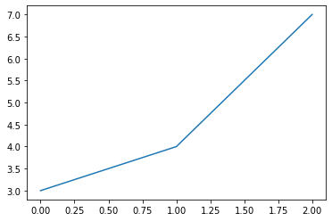

```python
pyplot.plot([0,1,2], [3,4,7])
```

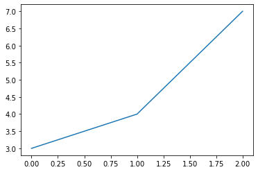

```python
x = [0,1,2]
y = [3,4,7]

pyplot.plot(x,y)
```

Goal: plot the fish populations.

x = year y = population

Problem: need to save results as a list! Right now, all we're doing is printing the current iteration of the loop.

```python
def fishPop(p, rate, totalCatch):

    population = p   #starting population

    years = []                    # <-- this is an "accumulator"
    populations = []              # <-- so is this


    #Look at population for next 10 years

    print("Year|Population")

    year = 0
    while (population >0 and year < 100):
        years.append(year)
        populations.append(population)
        formatString = "{0:^4}|{1:^10.2f}"
        print(  formatString.format(year,population)   )
        population = population*(1+rate)-totalCatch
        year = year+1

    return [years, populations]    # returning a list of lists: years and populations
```

**Question from class**: what does `append()` do?

Example:

`x = [1,2,3]`

`x.append(4)`

result: `x = [1,2,3,4]`

Example list accessor below:

```python
x = ["a", "b", "c"]
print(x[0])
```

```
a
```

Back to fish: now that our function returns something ( a list of two lists, `years` and `populations`)

```python
modelResults = fishPop(10000, .08, 1000)
```

```
Year|Population
 0  | 10000.00
 1  | 9800.00
 2  | 9584.00
 3  | 9350.72
 4  | 9098.78
 5  | 8826.68
 6  | 8532.81
 7  | 8215.44
 8  | 7872.67
 9  | 7502.49
 10 | 7102.69
 11 | 6670.90
 12 | 6204.57
 13 | 5700.94
 14 | 5157.02
 15 | 4569.58
 16 | 3935.14
 17 | 3249.95
 18 | 2509.95
 19 | 1710.75
 20 |  847.61
```

```python
modelResults[0]
```

```
[0, 1, 2, 3, 4, 5, 6, 7, 8, 9, 10, 11, 12, 13, 14, 15, 16, 17, 18, 19, 20]
```

```python
modelResults[1]
```

```
[10000,
 9800.0,
 9584.0,
 9350.720000000001,
 9098.777600000001,
 8826.679808000003,
 8532.814192640004,
 8215.439328051205,
 7872.6744742953015,
 7502.488432238926,
 7102.687506818041,
 6670.902507363485,
 6204.5747079525645,
 5700.94068458877,
 5157.0159393558715,
 4569.577214504342,
 3935.1433916646893,
 3249.9548629978644,
 2509.951252037694,
 1710.7473522007094,
 847.6071403767662]
```

Ok, let's plot it!

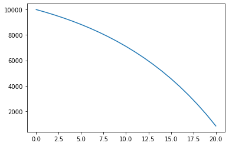

```python
pyplot.plot(modelResults[0], modelResults[1])
```

## Wednesday Sept 23

In the previous model, our function returned a vector.

Let's take a second to make sure we feel good about function returns, and how to use them.

Example: simple mathematical function.

f(x) = x^2 - 1

```python
def f(x):
    return x**2-1
```

```python
y = f(5)
```

```python
print(y)
```

```
24
```

Goal: graph the function f(x)

Command: pyplot.plot( [list of xvals], [list of yvals] )

Let's write a function that generates these lists: x-vals, y-vals. Input: allow the user to determine the range of x-values.

```python
def getVals(low, high):
    """ return lists of xvals and yvals for plotting

    input: low = left end of x range,
           high = right end of x range

    return:  list of lists:
          xvals  (a list of all x-vals to be plotted)
          yvals  (a list of all y-vals to be plotted)
    """

    xvals = []        # accumulator for x values
    yvals = []        # accumulator for y values

    for val in range(low,high):
        xvals.append(val)           # appending each value to the xvals list

    for xval in xvals:
        yvals.append( f(xval) )        #pluggin in all xvals to f(x), appending the results to yvals

    return [xvals, yvals]
```

```python
myResults = getVals(-10,10)
```

```python
type(myResults)
```

```
list
```

Our results are a list of two things: xvals, yvals.

Let's take a look!

```python
xvals = myResults[0]
xvals
```

```
[-10, -9, -8, -7, -6, -5, -4, -3, -2, -1, 0, 1, 2, 3, 4, 5, 6, 7, 8, 9]
```

```python
yvals = myResults[1]
yvals
```

```
[99, 80, 63, 48, 35, 24, 15, 8, 3, 0, -1, 0, 3, 8, 15, 24, 35, 48, 63, 80]
```

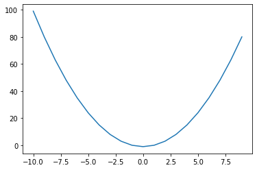

```python
import matplotlib.pyplot as pyplot

# importing the module
# we want to use the `plot()` function

pyplot.plot(xvals, yvals)
```

Fine and dandy, but, what if we want to plot other functions?

Neat python trick: we can pass functions as ARGUMENTS to other functions.

Let's do it for getVals: we'll add a third argument to specify a function:

```python
def getVals(low, high, myFunction):
    """ return lists of xvals and yvals for plotting

    input: low = left end of x range,
           high = right end of x range
           myFunction = a mathematical function computing y based on x

    return:  list of lists:
          xvals  (a list of all x-vals to be plotted)
          yvals  (a list of all y-vals to be plotted)
    """

    xvals = []        # accumulator for x values
    yvals = []        # accumulator for y values

    for val in range(low,high):
        xvals.append(val)           # appending each value to the xvals list

    for xval in xvals:
        yvals.append( myFunction(xval) )        #pluggin in all xvals to f(x), appending the results to yvals

    return [xvals, yvals]
```

```python
def theNameOfMyFunction(x):
    return (x+3)*(x-1)*(x-5)
```

```python
myResults = getVals(-5, 9, theNameOfMyFunction)

xvals = myResults[0]
yvals = myResults[1]
```

[figure not shown]

```python
pyplot.plot(xvals,yvals)
```

Example:

Solve

3x^2 - sin(2x+1)/e^(7x+2) = arctan(3pix)^2-2x^3

To solve -any- equation, move all terms to one side, solve =0:

```python
def getVals(low, high, myFunction):
    """ return lists of xvals and yvals for plotting

    input: low = left end of x range,
           high = right end of x range
           myFunction = a mathematical function computing y based on x

    return:  list of lists:
          xvals  (a list of all x-vals to be plotted)
          yvals  (a list of all y-vals to be plotted)
    """

    xvals = []        # accumulator for x values
    yvals = []        # accumulator for y values

    for val in range(low*10,high*10):
        xvals.append(val/10)           # appending each value to the xvals list

    for xval in xvals:
        yvals.append( myFunction(xval) )        #pluggin in all xvals to f(x), appending the results to yvals

    return [xvals, yvals]
```

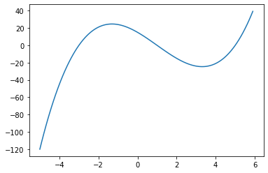

```python
myResults = getVals(-5, 6, theNameOfMyFunction)

xvals = myResults[0]
yvals = myResults[1]

pyplot.plot(xvals,yvals)
```

Newtwon's method.

First: Make a guess. x0.

Then, follow the tangent line to the axis. That x-value is the next guess.

Repeat.

Equation of a line: (point slope form)

y - y0 = m(x-x0)

Where (x0, y0) is a point on the line.

Here, x0 is our first guess.

m is slope. More on that later.

We're looking for the x-value where y =0. This x-val is the next guess.

0 - y0 = m(x-x0). Solve for x.

-y0/m = x - x0

-y0/m + x0 = x

"next x" = x0 - y0/m

Three parts:

- guess x0 (we choose)
- m (slope: change in y / change in x )
- y0 (the function value when x=x0)

Need two functions:

- function for y (find y vals based on x)
- function for the slope (find m, slope of the tangent line)

Starting example: y = f(x) = x^2 - 9.

Write function:

```python
def f(x):
    return x**2-9
```

Need a function for the slope.

m = (y2 - y1)/(x2-x1)

```python
def slope(f, x):
    """ inputs:  function f, x-val x

    return:  the slope of the line on that interval
    """

    # y2 = f(x+.001)
    # y1 = f(x)
    # x2 = x+.001
    # x1 = x

    return (f(x+.001)-f(x))/((x+.001)-x)
```

```python
slope(f,2)
```

```
4.00100000000014
```

Let's try by hand.

Let's guess x=25.

x0 = 25. Let's find x1:

x1 = x0-f(x0)/slope(x0)

```python
x0 = 25

x1 = x0 - f(x0)/slope(f, x0)
```

```python
print(x1)
```

```
12.680246395073228
```

```python
x2 = x1 - f(x1)/slope(f, x1)
```

```python
print(x2)
```

```
6.695241888604139
```

```python
x3 = x2 - f(x2)/slope(f, x2)
```

```python
print(x3)
```

```
4.019939842695299
```

```python
x4 = x3 - f(x3)/slope(f, x3)
print(x4)
```

```
3.129500410813397
```